# Project - COVID19

## 1.6 3. Optional Analysis: GDP per Capita and COVID-19 Mortality

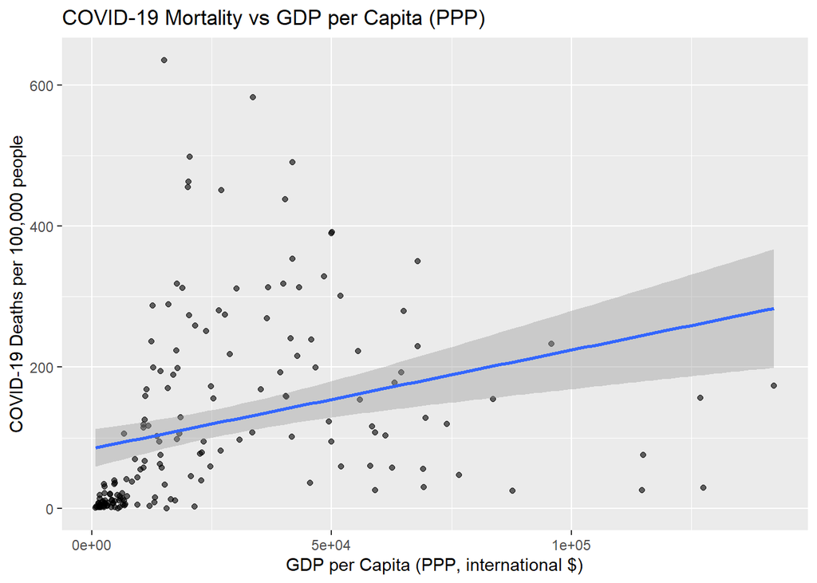

```
Call:
lm(formula = deaths_per_100k ~ gdp_pc, data = analysis_data)

Residuals:
    Min      1Q  Median      3Q     Max
-234.36  -83.84  -53.80   59.21  530.32

Coefficients:
             Estimate Std. Error t value Pr(>|t|)
(Intercept) 8.458e+01  1.377e+01   6.141 5.87e-09 ***
gdp_pc      1.399e-03  3.578e-04   3.910 0.000134 ***
---
Signif. codes:  0 '***' 0.001 '**' 0.01 '*' 0.05 '.' 0.1 ' ' 1

Residual standard error: 129.2 on 166 degrees of freedom
Multiple R-squared:  0.08432,   Adjusted R-squared:  0.0788
F-statistic: 15.29 on 1 and 166 DF,  p-value: 0.0001344
```

The regression model and scatterplot show the relationship between GDP per capita and COVID-19 mortality. The trend indicates whether wealthier countries experienced higher or lower COVID-19 death rates per 100,000 population. In our data, the slope suggests that the relationship is not purely protective: higher GDP countries may show higher mortality partly due to older populations, more international travel, and earlier exposure. This indicates that economic wealth alone does not determine pandemic outcomes; demographic and societal factors play a strong role.